# Module 1, Lesson 3: Navigating R and RStudio

In this Independent Guide, we will work through content covered in Lesson 3 but in a slightly modified order. After talking about assignments and objects, we will create two new R projects. We will create a new R script to put in one of these projects. Finally, we will install two R packages for use in the remainder of this course.

## Assignments and objects

When you open a new R session, there are many so-called ‘objects’ already in your environment. Numbers are objects (`1`, `2`, etc.). Slightly more interesting, type `pi` in the console, press ‘Enter’, and you will see the first digits of the number $\pi$ (the ratio of a circle’s circumference to its diameter). Your ‘Enter’ key may be labeled as ‘Return’ – on American keyboards it’s at the far right.

```r
pi
```

```
## [1] 3.141593
```

This works because `pi` is also an object that exists in any R session.

However, if you type the name of an object that doesn’t exist in the R console, you will get an error:

```r
x
```

```
## Error: object 'x' not found
```

This occurs because there is no object called `x` in a new R session. However, you can create any object you want. To do so, you use the assignment operator: `<-`. On the left of the assignment operator goes the name of the object you want to create, and on the right goes the object that you want to assign. As an example, we can create `x` and assign to it the value 10:

```r
x <- 10
```

Now `x` exists, and if we type it in the console we get its value:

```r
x
```

```
## [1] 10
```

We can now use `x` (and any other extant objects) to create *new* objects:

```r
y <- x + 2
```

Now we’ve created a second new object, called `y`, which is equal to 12. These assignments are static, meaning that if we change the value of `x`, we won’t also change the value of `y`, even though when we created it, it depended on `x`. For example, here we re-assign `x` and then ask R what the value of `y` is:

```r
x <- 2
y
```

```
## [1] 12
```

The object `y` has retained its original value despite `x` being changed.

Although `<-` is the intended way to create assignments, you can alternatively use the more simple `=`, as in

```r
x = 2
```

## R projects

R projects are files ending in `.Rproj`. You create such a file from within RStudio, and when you do so, then RStudio will treat the folder (or directory) that contains the `.Rproj` file as its “home directory”. Here we will create two R projects, entitled `GlobalFindex.Rproj` and `Lessons.Rproj`. The former is intended to contain code to create the Indicator Table and Figure 1.1. The latter is intended to be used for any other work you do in future Independent Guides.

If you are working from your own computer, first create two regular folders called GlobalFindex and Lessons (if you are working on posit.cloud, you may skip to the end of this section). Next, create a new R project by going to ‘File > New Project…’:

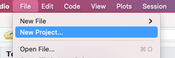

**Image description: creating a new R project**

A new window will pop up. Choose the option to create the project in an ‘Existing Directory’:

[figure not shown]

**Image description: choose ‘Existing Directory’ to put your project file inside an existing folder**

Then navigate to the folder named ‘GlobalFindex’ that you just created.

[figure not shown]

**Image description: navigate to the folder that you want to associate with your R project**

In addition, the bottom right of your screen, which shows the default or “home” directory that R is working from, indicates that it is indeed the GlobalFindex folder:

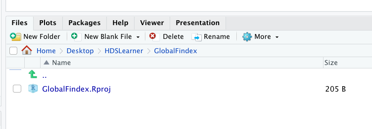

**Image description: the default or home directory is now the GlobalFindex folder**

Repeat this step for the folder named ‘Lessons’, i.e. create a new R project in the existing Lessons folder.

### Projects in posit.cloud

R projects are the **only** way to use RStudio on posit.cloud. In fact, you’ve already created a project on posit.cloud: recall that the first thing you did after logging in was create a new project named ‘GlobalFindex’.

To create a different project, look for the link in the top left that says ‘Your Workspace’. Click that link, which will take you to a list of all the projects you’ve made (there should be only one right now). Create a second new project called ‘Lessons’.

## Scripts

Whether you are working from your own computer or posit.cloud, for this next step, switch back to the ‘GlobalFindex’ project, which you can do by clicking the drop-down menu in the top right and choosing ‘GlobalFindex’ from the list:

[figure not shown]

**Image description: switching between R projects**

R scripts are files that you create in RStudio. From the ‘GlobalFindex’ project, open a new script by pressing ‘Cmd+Shift+N’ on your Mac or ‘Ctrl+Shift+N’ on your Windows computer. Or, from the dropdown menu, go to ‘File > New File > R Script’:

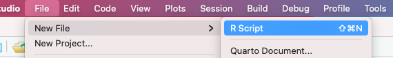

**Image description: creating a new script using dropdown menus**

A new window should have appeared in your RStudio console. It will be blank. R scripts are like recipes: they contain a list of step-by-step instructions for conducting your analysis. Also like recipes, scripts are not useful unless you actually implement the instructions, meaning that you can type code in an R script, but unless you run that code in the console, it won’t do anything.

Type something simple in your script, like `3+3`. Then, making sure your cursor is on that line of code, press ‘Cmd+Enter’ or ‘Ctrl+Enter’. That line of code should have been sent and run in the console. You have now made changes to your script that are not saved. To see this, the upper-left tab of your script should say `Untitled1*` in red font. The `Untited1` is a default name that R chooses, and the red font means that it contains unsaved changes. To save your script, press ‘Cmd+S’ or ‘Ctrl+S’ or go to ‘File > Save’ from the dropdown menu.

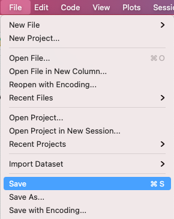

**Image description: saving a script**

We will put all of our code for creating the Indicator Table in this script, so save this script as `IndicatorTable.R`. For now, save it on your desktop or somewhere else that you’ll remember. In the upper-left tab of your script, where it previously said `Untitled1*` in red font, it should now say `IndicatorTable.R` in black font. Anything that you had put in this script up until the moment that you saved it is now permanently saved on your harddrive, even after you close RStudio (or navigate out of posit.cloud). If you make additional changes to the script, the font color will change back to red and an asterisk will appear after its name, both, indicating that this file now includes some code that is not saved. To see this, *delete* the `3+3` that you just put in the script. Now the file name looks like `IndicatorTable.R*`. Save your script again by pressing ‘Cmd+S’ or ‘Ctrl+S’, and the file name once again becomes `IndicatorTable.R`. In Module 2, you will begin to put code in this script.

## Packages

Packages are pre-constructed sets of objects, which may include functions or datasets. Some packages come pre-installed with R, perhaps the most important being the `base` package. However, the `base` package is unique in that you will never need to install or even load it. Using the terminology from the video, it is always and permanently a ‘State 1’ package.

Two packages that we will be using in this course that *do not* come pre-installed are `tidyverse` and `healthds`. At the moment you are first reading this, they are ‘State 3’ packages: they are not yet installed on your computer. The following sections describe how to install packages and will apply whether you are working on your own computer or on posit.cloud.

### How to install `tidyverse`

To install `tidyverse`, run the following line of code in your console:

```r
install.packages("tidyverse")
```

Installation of `tidyverse` may take a few minutes, since your computer will need to find the package on the internet, download it, and install it (along with other packages that `tidyverse` requires, called dependencies). A successful installation should print a message like this to the console:

```
##
##  /var/folders/h_/qfphhh756972g9ktfy3c_x3r0000gp/T//Rtmplu2V7C/downloaded_packages
```

Upon successful installation, the `tidyverse` package is now in State 2: installed on your computer but not yet loaded into your R session. Run the following code to move `tidyverse` from State 2 to State 1.

```r
library(tidyverse)
```

You will not need to re-install `tidyverse` if you close RStudio, but you will need to re-load it, i.e. using the `library` command. Therefore, you should put `library(tidyverse)` at the top of any script inside which you intend to use functions from `tidyverse`. Put `library(tidyverse)` on the very first line of `IndicatorTable.R` now and save the script.

### How to install `healthds`

Installing the `healthds` package is slightly more complicated because it has been developed specifically for learners in this course, and it is not located in the usual repositories that the `install.packages` function would look in. To install `healthds`, we first need to install and load a package called `remotes`:

```r
install.packages("remotes")
library(remotes)
```

Next, we will use a function from the `remotes` package called `install_git`. This function acts similarly to `install.packages` but allows us to install packages that are hosted on GitHub, a repository where any user can develop and publicly share software. To install `healthds`, run the following line of code (it is easiest to copy-paste this directly into your R console):

```r
install_git("https://github.com/umich-biostatistics/healthds", upgrade = "never")
```

If you run the above line of code without first having installed and loaded `remotes`, you will get an error message that the function `install_git` is not found. Upon successfully running this line of code, the `healthds` package will be in State 2, and we can move it to State 1 by using `library`:

```r
library(healthds)
```

You will not need the `healthds` package for creating the Indicator Table or Figure 1.1, so you do not need to put `library(healthds)` at the top of `IndicatorTable.R`. We will wait until the next Module’s Independent Guide to create a script that uses `healthds`. For now it is sufficient to have installed it on our computer.